# Data description: Aggregate behavior

Erik Ø. Sørensen

05 august, 2025

This is to calculate the descriptives in the subsection on aggregate behavior in “Linking Social and Personal Preferences: Theory and Experiment” by William R. Zame, Bertil Tungodden, Erik Ø. Sørensen, Shachar Kariv, and Alexander W. Cappelen.

# Distribution of choices in the *Social Choice* treatment

```r
average_social_decisions <- mmzame_decisions %>%
  filter(treatment=="dictator") %>%
  mutate(yshare = y/(y+x)) %>%
  group_by(id) %>%
  summarize(mean_yshare = mean(yshare)) %>%
  mutate(selfish = (mean_yshare>0.95),
         impartial = (abs(mean_yshare - 0.5)<0.05))
```

Now, we can count the different types:

```r
(type_table <- average_social_decisions %>%
  with(table(selfish,impartial)))
```

```
##        impartial
## selfish FALSE TRUE
##   FALSE   154   19
##   TRUE    103    0
```

```r
type_table / sum(type_table)
```

```
##        impartial
## selfish      FALSE       TRUE
##   FALSE 0.55797101 0.06884058
##   TRUE  0.37318841 0.00000000
```

How many were even more selfless?

```r
average_social_decisions %>% filter(mean_yshare<0.5) %>%
  arrange(mean_yshare)
```

```
## # A tibble: 14 × 4
##       id mean_yshare selfish impartial
##    <dbl>       <dbl> <lgl>   <lgl>
##  1   737       0.113 FALSE   FALSE
##  2   427       0.173 FALSE   FALSE
##  3   522       0.428 FALSE   FALSE
##  4   605       0.44  FALSE   FALSE
##  5   619       0.442 FALSE   FALSE
##  6   701       0.445 FALSE   FALSE
##  7   538       0.456 FALSE   TRUE
##  8   102       0.460 FALSE   TRUE
##  9   125       0.472 FALSE   TRUE
## 10   104       0.479 FALSE   TRUE
## 11   757       0.48  FALSE   TRUE
## 12   316       0.484 FALSE   TRUE
## 13   320       0.495 FALSE   TRUE
## 14   329       0.499 FALSE   TRUE
```

```r
average_symmetric_decisions <- mmzame_decisions %>%
  filter(treatment %in% c("moral", "risk")) %>%
  mutate(share_cheapest = if_else(maxy>maxx, y/(y+x), x/(y+x))) %>%
  group_by(treatment, id) %>%
  summarize(mean_cheapest = mean(share_cheapest)) %>%
  left_join(average_social_decisions, by="id") %>%
  ungroup() %>%
  mutate(treatmentf = fct_recode(factor(treatment, levels=c("risk","moral")),
         "Personal Risk" = "risk",
         "Social Risk" = "moral"))
```

How many are in the extreme groups?

```r
average_symmetric_decisions %>%
  mutate(more_than_95p = (mean_cheapest > 0.95)) %>%
  group_by(treatmentf, more_than_95p) %>%
  summarize(n = n()) %>% gt::gt()
```

| more_than_95p | n |
| --- | --- |
| Personal Risk |  |
| FALSE | 235 |
| TRUE | 41 |
| Social Risk |  |
| FALSE | 246 |
| TRUE | 30 |

```r
average_symmetric_decisions %>%
  mutate(less_than_55p = (mean_cheapest < 0.55))%>%
  group_by(treatmentf, less_than_55p) %>%
  summarize(n = n()) %>% gt::gt()
```

| less_than_55p | n |
| --- | --- |
| Personal Risk |  |
| FALSE | 267 |
| TRUE | 9 |
| Social Risk |  |
| FALSE | 267 |
| TRUE | 9 |

```r
average_symmetric_decisions |> filter(mean_cheapest<0.5) |> gt::gt()
```

| treatment | id | mean_cheapest | mean_yshare | selfish | impartial | treatmentf |
| --- | --- | --- | --- | --- | --- | --- |
| moral | 406 | 0.4956205 | 0.5319446 | FALSE | TRUE | Social Risk |
| risk | 306 | 0.4997005 | 0.6475193 | FALSE | FALSE | Personal Risk |
| risk | 313 | 0.2158955 | 0.7003826 | FALSE | FALSE | Personal Risk |
| risk | 542 | 0.4918443 | 0.8673798 | FALSE | FALSE | Personal Risk |

## Extreme utilitarianism and Rawlsianism

```r
xtremesU <- mmzame_decisions |>
  mutate(px_high = ifelse(maxx>maxy,1,0),
                           share_self = y/(x+y)) |>
  filter(treatment=="dictator") |>
  group_by(id, px_high) |>
  summarize( share_self = mean(share_self)) |>
  pivot_wider(id_cols = id, names_from = "px_high", names_prefix = "HIGH_Px_", values_from = share_self) |>
  mutate(utilitarian01 = (HIGH_Px_0>0.99) * (HIGH_Px_1<0.01),
         utilitarian05 = (HIGH_Px_0>0.95) * (HIGH_Px_1<0.05),
         utilitarian10 = (HIGH_Px_0>0.90) * (HIGH_Px_1<0.10))
```

[output not shown]

```r
xtremesU |> filter(utilitarian10==1) |>
  ungroup() |>
  gt::gt() |>
  gt::tab_spanner(label="Share to self", columns=2:3)
```

[output not shown]

Another “Rawlsian” way of thinking is that the difference in what is allocated to x and y is very small,

```r
mmzame_decisions |> filter(treatment=="dictator") |>
  mutate(reldiff = abs(x-y)/(x+y),
         selfshare = y/(x+y)) |>
  group_by(id) |>
  summarize(max_reldiff = max(reldiff),
            mean_reldiff = mean(reldiff),
            max_selfshare = max(selfshare),
            min_selfshare = min(selfshare)) |>
  arrange(mean_reldiff) |>
  head() |>
  gt::gt()
```

| id | max_reldiff | mean_reldiff | max_selfshare | min_selfshare |
| --- | --- | --- | --- | --- |
| 414 | 0.1724138 | 0.01233283 | 0.5862069 | 0.4967742 |
| 320 | 1.0000000 | 0.03855873 | 0.6393443 | 0.0000000 |
| 406 | 1.0000000 | 0.06651473 | 1.0000000 | 0.4671815 |
| 314 | 0.9057239 | 0.18945058 | 0.9528620 | 0.1228571 |
| 329 | 1.0000000 | 0.24208812 | 1.0000000 | 0.0000000 |
| 115 | 1.0000000 | 0.25521603 | 1.0000000 | 0.0000000 |

# graph with all treatments

```r
bar_data <- average_social_decisions %>%
  bind_rows(average_symmetric_decisions) %>%
  mutate( treatment = if_else(is.na(treatment), "social", treatment)) %>%
  mutate(treatmentf = fct_recode(factor(treatment, levels=c("social", "risk","moral")),
                                 "Social Choice" = "social",
                                 "Personal Risk" = "risk",
                                 "Social Risk" = "moral")) %>%
  mutate( yshare = if_else(treatment=="social", mean_yshare, mean_cheapest)) %>%
  dplyr::select(id, treatmentf, yshare)
```

Having created the dataset, we now want to print a bar chart with grouped categories. We need to group the outcome, `yshare`, into groups—we can use `cut`.

```r
bar_data <- bar_data %>% mutate(ygroup = cut_width(yshare, 0.10, boundary=1, closed="right"))
```

We want to present fractions at each group—and since we want `ggplot` to make room for the zero-height bars, we do the counting and the completion ourselves

```r
bar_fractions <- bar_data %>%
  group_by(treatmentf, ygroup) %>%
  tally() %>%
  ungroup() %>%
  complete(treatmentf,ygroup, fill=list(n=0)) %>%
  group_by(treatmentf) %>%
  mutate( fraction = n/sum(n))
```

Now, it should be possible to use ggplot to figure out how to present the groups:

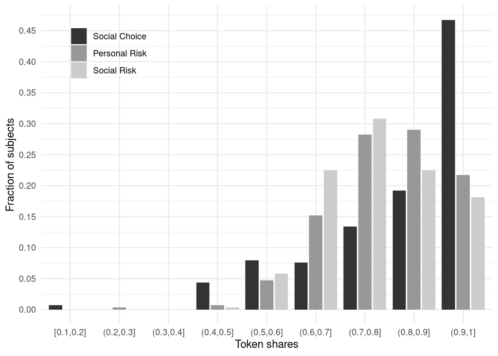

```r
bar_fractions %>% ggplot(aes(x=ygroup, y=fraction, group=treatmentf, fill=treatmentf)) +
  geom_bar(stat="identity", position=position_dodge2()) +
  labs(x = "Token shares",
       y = "Fraction of subjects") +
  theme_minimal() +
  theme(legend.title=element_blank()) +
  scale_fill_grey() +
  scale_y_continuous(breaks = c(0, 0.05, 0.1, 0.15,0.2,0.25,0.3,0.35,0.4,0.45,0.5)) +
  theme(legend.position = c(0.15,0.85))
```

```r
ggsave(here::here("graphs","aggregate_choices.pdf"), width = 16, height = 10, units = "cm", device = cairo_pdf)
ggsave(here::here("graphs","aggregate_choices.eps"), width = 16, height = 10, units = "cm", device = cairo_ps)
```